# Lab Vision Systems: Session 4

## Today:

### 1: Solution Assignment 2

### 2: Optimizers

### 3: CNN Architectures

### 4: Transfer Learning

## Some Comments about the Assignments

- Do not just show plots or numbers. All results need to be interpreted:
  - Why is a model is better than others
  - What is going on in this plot
  - Which classes does the model confuse. Does that make sense?
  - ...

[figure not shown]

# 1: Solution Assignment 2

By Jan Nogga & Fabrice Beaumont

# 2: Optimizers

# 3: CNN Architectures

# 4: Transfer Learning

In this tutorial, you will learn how to train your network using transfer learning. You can read more about the transfer learning at `cs231n notes http://cs231n.github.io/transfer-learning/

Quoting this notes,

```
In practice, very few people train an entire Convolutional Network
from scratch (with random initialization), because it is relatively
rare to have a dataset of sufficient size. Instead, it is common to
pretrain a ConvNet on a very large dataset (e.g. ImageNet, which
contains 1.2 million images with 1000 categories), and then use the
ConvNet either as an initialization or a fixed feature extractor for
the task of interest.
```

These two major transfer learning scenarios looks as follows:

- **Finetuning the CNN**: Instead of random initializaion, we initialize the network with a pretrained network, like the one that is trained on the Imagenet dataset. Rest of the training looks as usual.
- **CNN as fixed feature extractor**: Here, we will freeze the weights for all of the network except that of the final fully connected classifier. This last fully connected layer is replaced with a new one with random weights and only this layer is trained.

```python
import os
from tqdm import tqdm
import numpy as np
import matplotlib.pyplot as plt

import torch
import torch.nn as nn
import torchvision
from torchvision import datasets, models, transforms
```

## Data Loading

We will use torchvision and torch.utils.data packages for loading the data.

The problem we're going to solve today is to train a model to classify ants and bees. We have about 120 training images each for ants and bees. There are 75 validation images for each class. Usually, this is a very small dataset to generalize upon, if trained from scratch. Since we are using transfer learning, we should be able to generalize reasonably well.

This dataset is a very small subset of imagenet.

```python
# !wget https://download.pytorch.org/tutorial/hymenoptera_data.zip #Download the data from
```

```python
# Data augmentation and normalization for training
# Just normalization for validation
data_transforms = {
    'train': transforms.Compose([
        transforms.RandomResizedCrop(224),
        transforms.RandomHorizontalFlip(),
        transforms.ToTensor(),
        transforms.Normalize([0.485, 0.456, 0.406], [0.229, 0.224, 0.225])
    ]),
    'val': transforms.Compose([
        transforms.Resize(256),
        transforms.CenterCrop(224),
        transforms.ToTensor(),
        transforms.Normalize([0.485, 0.456, 0.406], [0.229, 0.224, 0.225])
    ]),
}

data_dir = 'data/hymenoptera_data'

train_dataset = datasets.ImageFolder(os.path.join(data_dir, "train"), data_transforms["train"])
valid_dataset = datasets.ImageFolder(os.path.join(data_dir, "val"), data_transforms["val"])

N_train = len(train_dataset)
N_valid = len(valid_dataset)
print(f"Training set size: {N_train} images")
print(f"Valdiation set size: {N_valid} images")

train_loader = torch.utils.data.DataLoader(train_dataset, batch_size=32, shuffle=True, num_workers=4)
valid_loader = torch.utils.data.DataLoader(valid_dataset, batch_size=32, shuffle=True, num_workers=4)
```

```
Training set size: 244 images
Valdiation set size: 153 images
```

```python
class_names = train_dataset.classes
print(class_names)
```

```
['ants', 'bees']
```

```python
device = torch.device("cuda" if torch.cuda.is_available() else "cpu")
```

## Visualizing some Images

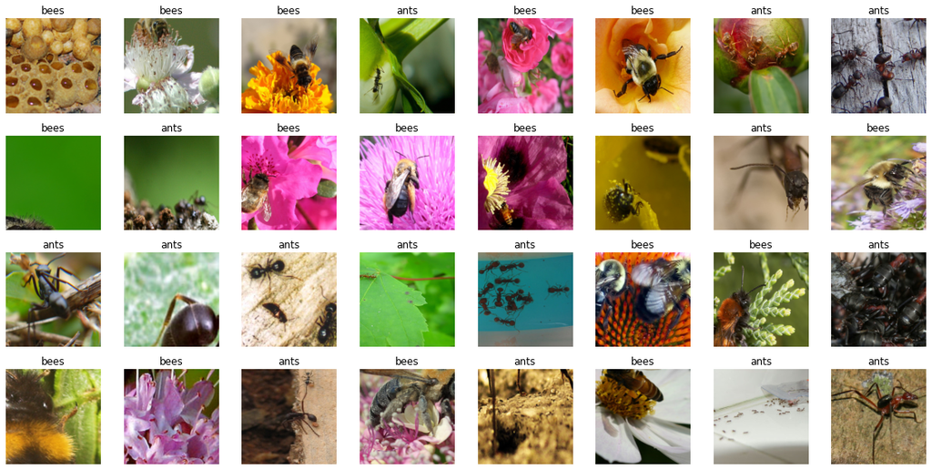

```python
def show_grid(data, titles=None):
    """Imshow for Tensor."""
    data = data.numpy().transpose((0, 2, 3, 1))
    mean = np.array([0.485, 0.456, 0.406])
    std = np.array([0.229, 0.224, 0.225])
    data = std * data + mean
    data = np.clip(data, 0, 1)

    plt.figure(figsize=(8*2, 4*2))
    for i in range(32):
        plt.subplot(4,8,i+1)
        plt.imshow(data[i])
        plt.axis("off")
        if titles is not None:
            plt.title(titles[i])
    plt.tight_layout()
    plt.show()

# Get a batch of training data and displaying it
inputs, classes = next(iter(train_loader))
titles = [class_names[x] for x in classes]

show_grid(inputs, titles=titles)
```

## Main Code

```python
def train_epoch(model, train_loader, optimizer, criterion, epoch, device):
    """ Training a model for one epoch """

    loss_list = []
    for i, (images, labels) in enumerate(train_loader):
        images = images.to(device)
        labels = labels.to(device)

        # Clear gradients w.r.t. parameters
        optimizer.zero_grad()

        # Forward pass to get output/logits
        outputs = model(images)

        # Calculate Loss: softmax --> cross entropy loss
        loss = criterion(outputs, labels)
        loss_list.append(loss.item())

        # Getting gradients w.r.t. parameters
        loss.backward()

        # Updating parameters
        optimizer.step()

    mean_loss = np.mean(loss_list)
    return mean_loss, loss_list


@torch.no_grad()
def eval_model(model, eval_loader, criterion, device):
    """ Evaluating the model for either validation or test """
    correct = 0
    total = 0
    loss_list = []

    for images, labels in eval_loader:
        images = images.to(device)
        labels = labels.to(device)

        # Forward pass only to get logits/output
        outputs = model(images)

        loss = criterion(outputs, labels)
        loss_list.append(loss.item())

        # Get predictions from the maximum value
        preds = torch.argmax(outputs, dim=1)
        correct += len( torch.where(preds==labels)[0] )
        total += len(labels)

    # Total correct predictions and loss
    accuracy = correct / total * 100
    loss = np.mean(loss_list)

    return accuracy, loss


def train_model(model, optimizer, scheduler, criterion, train_loader, valid_loader, num_epochs):
    """ Training a model for a given number of epochs"""

    train_loss = []
    val_loss =  []
    loss_iters = []
    valid_acc = []

    for epoch in range(num_epochs):

        # validation epoch
        model.eval()  # important for dropout and batch norms
        accuracy, loss = eval_model(
                    model=model, eval_loader=valid_loader,
                    criterion=criterion, device=device
            )
        valid_acc.append(accuracy)
        val_loss.append(loss)

        # training epoch
        model.train()  # important for dropout and batch norms
        mean_loss, cur_loss_iters = train_epoch(
                model=model, train_loader=train_loader, optimizer=optimizer,
                criterion=criterion, epoch=epoch, device=device
            )
        scheduler.step()
        train_loss.append(mean_loss)
        loss_iters = loss_iters + cur_loss_iters

        if(epoch % 5 == 0 or epoch==num_epochs-1):
            print(f"Epoch {epoch+1}/{num_epochs}")
            print(f"    Train loss: {round(mean_loss, 5)}")
            print(f"    Valid loss: {round(loss, 5)}")
            print(f"    Accuracy: {accuracy}%")
            print("\n")

    print(f"Training completed")
    return train_loss, val_loss, loss_iters, valid_acc
```

```python
def save_model(model, optimizer, epoch, stats):
    """ Saving model checkpoint """

    if(not os.path.exists("models")):
        os.makedirs("models")
    savepath = f"models/checkpoint_epoch_{epoch}.pth"

    torch.save({
        'epoch': epoch,
        'model_state_dict': model.state_dict(),
        'optimizer_state_dict': optimizer.state_dict(),
        'stats': stats
    }, savepath)
    return


def load_model(model, optimizer, savepath):
    """ Loading pretrained checkpoint """

    checkpoint = torch.load(savepath)
    model.load_state_dict(checkpoint['model_state_dict'])
    optimizer.load_state_dict(checkpoint['optimizer_state_dict'])
    epoch = checkpoint["epoch"]
    stats = checkpoint["stats"]

    return model, optimizer, epoch, stats


def smooth(f, K=5):
    """ Smoothing a function using a low-pass filter (mean) of size K """
    kernel = np.ones(K) / K
    f = np.concatenate([f[:int(K//2)], f, f[int(-K//2):]])  # to account for boundaries
    smooth_f = np.convolve(f, kernel, mode="same")
    smooth_f = smooth_f[K//2: -K//2]  # removing boundary-fixes
    return smooth_f

def set_random_seed(random_seed=None):
    """
    Using random seed for numpy and torch
    """
    if(random_seed is None):
        random_seed = 13
    os.environ['PYTHONHASHSEED'] = str(random_seed)
    np.random.seed(random_seed)
    torch.manual_seed(random_seed)
    torch.cuda.manual_seed_all(random_seed)
    return
```

## Model

We get a pretrained ResNet-18 model. We keep the convolutional part, but drop the fully-connected classification head and make one of our own.

```python
set_random_seed()
```

```python
# downloading pretrained model
model = models.resnet18(pretrained=True)  # https://github.com/pytorch/vision/blob/master/torchvision/models/resnet.py

# replacing classification head
num_nuerons = model.fc.in_features
model.fc = nn.Linear(num_nuerons, 2)

model = model.to(device)
```

```python
# classification loss function
criterion = nn.CrossEntropyLoss()

# Observe that all parameters are being optimized
optimizer = torch.optim.Adam(model.parameters(), lr=3e-4)

# Decay LR by a factor of 0.1 every 7 epochs
scheduler = torch.optim.lr_scheduler.StepLR(optimizer, step_size=7, gamma=0.1)
```

## Training and Evaluation

The number of images is very small, so it trains very fast on a GPU

```python
train_loss, val_loss, loss_iters, valid_acc = train_model(
        model=model, optimizer=optimizer, scheduler=scheduler, criterion=criterion,
        train_loader=train_loader, valid_loader=valid_loader, num_epochs=30
    )
```

```
    Train loss: 0.38392
    Valid loss: 0.69133
    Accuracy: 60.78431372549019%


    Train loss: 0.15778
    Valid loss: 0.70753
    Accuracy: 86.27450980392157%


    Train loss: 0.09225
    Valid loss: 0.4087
    Accuracy: 88.88888888888889%


    Train loss: 0.04841
    Valid loss: 0.37499
    Accuracy: 92.81045751633987%


    Train loss: 0.06568
    Valid loss: 0.38601
    Accuracy: 92.81045751633987%


    Train loss: 0.04343
    Valid loss: 0.38962
    Accuracy: 92.81045751633987%


    Train loss: 0.04338
    Valid loss: 0.36781
    Accuracy: 92.81045751633987%


Training completed
```

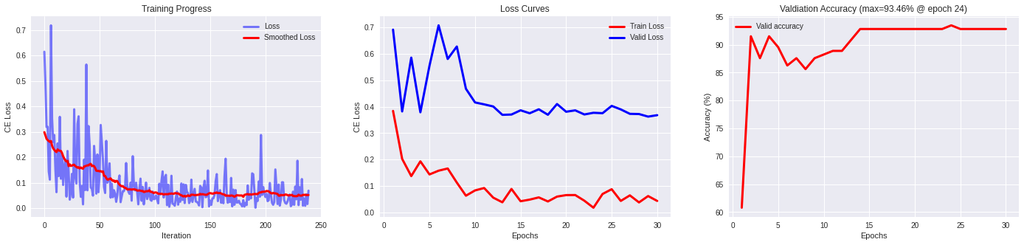

```python
plt.style.use('seaborn')
fig, ax = plt.subplots(1,3)
fig.set_size_inches(24,5)

smooth_loss = smooth(loss_iters, 31)
ax[0].plot(loss_iters, c="blue", label="Loss", linewidth=3, alpha=0.5)
ax[0].plot(smooth_loss, c="red", label="Smoothed Loss", linewidth=3, alpha=1)
ax[0].legend(loc="best")
ax[0].set_xlabel("Iteration")
ax[0].set_ylabel("CE Loss")
ax[0].set_title("Training Progress")

epochs = np.arange(len(train_loss)) + 1
ax[1].plot(epochs, train_loss, c="red", label="Train Loss", linewidth=3)
ax[1].plot(epochs, val_loss, c="blue", label="Valid Loss", linewidth=3)
ax[1].legend(loc="best")
ax[1].set_xlabel("Epochs")
ax[1].set_ylabel("CE Loss")
ax[1].set_title("Loss Curves")

epochs = np.arange(len(val_loss)) + 1
ax[2].plot(epochs, valid_acc, c="red", label="Valid accuracy", linewidth=3)
ax[2].legend(loc="best")
ax[2].set_xlabel("Epochs")
ax[2].set_ylabel("Accuracy (%)")
ax[2].set_title(f"Valdiation Accuracy (max={round(np.max(valid_acc),2)}% @ epoch {np.argmax(valid_acc)+1})")

plt.show()
```

## ConvNet as fixed feature extractor

Here, we need to freeze all the network except the final layer. We need to set requires_grad == False to freeze the parameters so that the gradients are not computed in backward().

You can read more about this in the documentation `here http://pytorch.org/docs/notes/autograd.html#excluding-subgraphs-from-backward

```python
set_random_seed()
```

```python
fixedModel = torchvision.models.resnet18(pretrained=True)
for param in fixedModel.parameters():
    param.requires_grad = False

# Parameters of newly constructed modules have requires_grad=True by default
num_logits = fixedModel.fc.in_features
fixedModel.fc = nn.Linear(num_logits, 2)
fixedModel = fixedModel.to(device)
```

```python
# classification loss function
criterion = nn.CrossEntropyLoss()

# Observe that all parameters are being optimized
optimizer = torch.optim.Adam(fixedModel.parameters(), lr=3e-4)

# Decay LR by a factor of 0.1 every 7 epochs
scheduler = torch.optim.lr_scheduler.StepLR(optimizer, step_size=7, gamma=0.1)
```

On CPU this will take about half the time compared to previous scenario. This is expected as gradients don't need to be computed for most of the network. However, forward does need to be computed.

```python
train_loss, val_loss, loss_iters, valid_acc = train_model(
        model=fixedModel, optimizer=optimizer, scheduler=scheduler, criterion=criterion,
        train_loader=train_loader, valid_loader=valid_loader, num_epochs=30
    )
```

```
    Train loss: 0.67684
    Valid loss: 0.69133
    Accuracy: 60.78431372549019%


    Train loss: 0.44714
    Valid loss: 0.44448
    Accuracy: 86.9281045751634%


    Train loss: 0.38514
    Valid loss: 0.38162
    Accuracy: 90.19607843137256%


    Train loss: 0.38343
    Valid loss: 0.37308
    Accuracy: 90.19607843137256%


    Train loss: 0.39578
    Valid loss: 0.36716
    Accuracy: 90.19607843137256%


    Train loss: 0.38034
    Valid loss: 0.37164
    Accuracy: 90.19607843137256%


    Train loss: 0.37885
    Valid loss: 0.36641
    Accuracy: 90.19607843137256%


Training completed
```

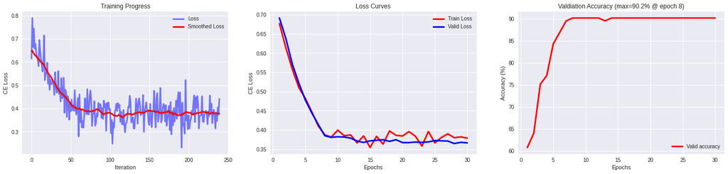

```python
plt.style.use('seaborn')
fig, ax = plt.subplots(1,3)
fig.set_size_inches(24,5)

smooth_loss = smooth(loss_iters, 31)
ax[0].plot(loss_iters, c="blue", label="Loss", linewidth=3, alpha=0.5)
ax[0].plot(smooth_loss, c="red", label="Smoothed Loss", linewidth=3, alpha=1)
ax[0].legend(loc="best")
ax[0].set_xlabel("Iteration")
ax[0].set_ylabel("CE Loss")
ax[0].set_title("Training Progress")

epochs = np.arange(len(train_loss)) + 1
ax[1].plot(epochs, train_loss, c="red", label="Train Loss", linewidth=3)
ax[1].plot(epochs, val_loss, c="blue", label="Valid Loss", linewidth=3)
ax[1].legend(loc="best")
ax[1].set_xlabel("Epochs")
ax[1].set_ylabel("CE Loss")
ax[1].set_title("Loss Curves")

epochs = np.arange(len(val_loss)) + 1
ax[2].plot(epochs, valid_acc, c="red", label="Valid accuracy", linewidth=3)
ax[2].legend(loc="best")
ax[2].set_xlabel("Epochs")
ax[2].set_ylabel("Accuracy (%)")
ax[2].set_title(f"Valdiation Accuracy (max={round(np.max(valid_acc),2)}% @ epoch {np.argmax(valid_acc)+1})")

plt.show()
```

# Assignment 4

### Data Gathering

- Gather a dataset for humanoid robot v.s. person classification. For the robot images, you can sample frames from the videos below or you can scrap the from Google some others. For the person images, scrap them from Google.
  - How to scrap images
    - https://intprogrammer.medium.com/how-to-scrape-google-for-images-to-train-your-machine-learning-classifiers-on-565076972ce
    - https://towardsdatascience.com/classifying-images-of-alcoholic-beverages-with-fast-ai-34c4560b5543

```
 - Robot videos
    - https://www.youtube.com/watch?v=JdP0AG0FqwY
    - https://www.youtube.com/watch?v=6ldHWWHfeBc&t=5s
    - https://www.youtube.com/watch?v=WJKc56uUuF8
    - https://www.youtube.com/watch?v=RG205OwGdSg
    - https://www.youtube.com/watch?v=yVdB_0ry53o
    - https://www.youtube.com/watch?v=TWNvSHpMrSM
    - https://www.youtube.com/watch?v=UsmBD2_3FH8
    - https://www.youtube.com/watch?v=WGKo_6IkFBY
    - https://www.youtube.com/watch?v=G6xE7uWt6Fo&t=1s
    - https://www.youtube.com/watch?v=G9llFqAwI-8&t=17s
    - https://www.youtube.com/watch?v=t8Ni5cB9FCc&t=21s
    - https://www.youtube.com/watch?v=CLkcznptenE
    - https://www.youtube.com/watch?v=-FQOZTsEA1Y
    - https://www.youtube.com/watch?v=hkZAMO0y0Hs
    - https://www.youtube.com/watch?v=9saVpA3wIbU
    - https://www.youtube.com/watch?v=RC7ZNXclWWY
```

- Something like 120 frames with robot and 120 frames for person is enough. **Do not use consecutive frames**
  - Label robot images as *robot1.png*, *robot2.png*,..., and the others as *person1.png*, ...
- Enlarge this dataset **offline** using spatial data augmention (e.g. mirror, flip, ...).
  - Save these images with the following convention: *robot1.png* $\rightarrow$ *robot1_aug1.png*, *robot1_aug2.png*, ...
- Use some other augmentations (crops, color jitter, ...) in an online manner.
- Extra points:
  - Use **CutMix** as an online augmentation. See https://arxiv.org/pdf/1905.04899.pdf

### Experiments:

Using your Robot v.s. Human dataset:

- Fine-tune VGG, ResNet and DenseNet for your custom dataset of humanoid robot classification (Binary classification Robot v.s. Human) and compare them.
- Compare the following: Fine-Tuned ResNet and ResNet as fixed feature extractor with an MLP classifiers
- Extra Point:
  - Train a ResNet feature extractor with an SVM classifier. You can use sklearn for the SVM. Compare this model to the Fine-Tuned Resnet and the Fixed-ResNet + MLP classifier

#### **Due Date**: Sunday 13th June at 23:59

#### Submit it by mail using the subject: **CudaLab: Assignment4**

#### Send me the following: Jupyter Notebook after running, Jupyter export as html, any other .py files or images used.

# References

- https://pytorch.org/tutorials/beginner/transfer_learning_tutorial.html
- https://www.deeplearningbook.org/
- http://cs231n.stanford.edu/
- https://towardsdatascience.com/classifying-images-of-alcoholic-beverages-with-fast-ai-34c4560b5543

**Angel Villar-Corrales**

- **Email**: villar@ais.uni-bonn.de
- **Website**: angelvillarcorrales.com